# STATS 415 - Homework 2

Marian L. Schmidt

January 29, 2016

```r
library(ISLR)
library(dplyr) # summary stats
library(pander) # for making tables
```

```r
# 1a: Read the Data into R
college <- read.csv("data/College.csv")

#1b: Make the first column of the data frame the row names
rownames(college) = college[,1]
# Then remove the extra column
college$X = NULL # same as college <- college[,-1]
dim(college) # Number of rows, Number of Columns
```

```
## [1] 777  18
```

```r
str(college) # Tells us the type of data that is in college
```

```
## 'data.frame':    777 obs. of  18 variables:
##  $ Private    : Factor w/ 2 levels "No","Yes": 2 2 2 2 2 2 2 2 2 2 ...
##  $ Apps       : int  1660 2186 1428 417 193 587 353 1899 1038 582 ...
##  $ Accept     : int  1232 1924 1097 349 146 479 340 1720 839 498 ...
##  $ Enroll     : int  721 512 336 137 55 158 103 489 227 172 ...
##  $ Top10perc  : int  23 16 22 60 16 38 17 37 30 21 ...
##  $ Top25perc  : int  52 29 50 89 44 62 45 68 63 44 ...
##  $ F.Undergrad: int  2885 2683 1036 510 249 678 416 1594 973 799 ...
##  $ P.Undergrad: int  537 1227 99 63 869 41 230 32 306 78 ...
##  $ Outstate   : int  7440 12280 11250 12960 7560 13500 13290 13868 15595 10468 ...
##  $ Room.Board : int  3300 6450 3750 5450 4120 3335 5720 4826 4400 3380 ...
##  $ Books      : int  450 750 400 450 800 500 500 450 300 660 ...
##  $ Personal   : int  2200 1500 1165 875 1500 675 1500 850 500 1800 ...
##  $ PhD        : int  70 29 53 92 76 67 90 89 79 40 ...
##  $ Terminal   : int  78 30 66 97 72 73 93 100 84 41 ...
##  $ S.F.Ratio  : num  18.1 12.2 12.9 7.7 11.9 9.4 11.5 13.7 11.3 11.5 ...
##  $ perc.alumni: int  12 16 30 37 2 11 26 37 23 15 ...
##  $ Expend     : int  7041 10527 8735 19016 10922 9727 8861 11487 11644 8991 ...
##  $ Grad.Rate  : int  60 56 54 59 15 55 63 73 80 52 ...
```

Our data has 777 colleges and 18 variables. `Private` is a binary, qualitative, nominal variable while all of the other columns (e.g. `Enroll`, `Top10perc`) are continuous, quantitative ratio variables. The `S.F.Ratio`, which represents the student to faculty ratio is a numerical data structure while all the others are integers.

### 1.c.ii and 1.c.ii

```r
#1c
summary(college)
```

```
##  Private        Apps           Accept          Enroll       Top10perc
##  No :212   Min.   :   81   Min.   :   72   Min.   :  35   Min.   : 1.00
##  Yes:565   1st Qu.:  776   1st Qu.:  604   1st Qu.: 242   1st Qu.:15.00
##            Median : 1558   Median : 1110   Median : 434   Median :23.00
##            Mean   : 3002   Mean   : 2019   Mean   : 780   Mean   :27.56
##            3rd Qu.: 3624   3rd Qu.: 2424   3rd Qu.: 902   3rd Qu.:35.00
##            Max.   :48094   Max.   :26330   Max.   :6392   Max.   :96.00
##    Top25perc      F.Undergrad     P.Undergrad         Outstate
##  Min.   :  9.0   Min.   :  139   Min.   :    1.0   Min.   : 2340
##  1st Qu.: 41.0   1st Qu.:  992   1st Qu.:   95.0   1st Qu.: 7320
##  Median : 54.0   Median : 1707   Median :  353.0   Median : 9990
##  Mean   : 55.8   Mean   : 3700   Mean   :  855.3   Mean   :10441
##  3rd Qu.: 69.0   3rd Qu.: 4005   3rd Qu.:  967.0   3rd Qu.:12925
##  Max.   :100.0   Max.   :31643   Max.   :21836.0   Max.   :21700
##    Room.Board       Books           Personal         PhD
##  Min.   :1780   Min.   :  96.0   Min.   : 250   Min.   :  8.00
##  1st Qu.:3597   1st Qu.: 470.0   1st Qu.: 850   1st Qu.: 62.00
##  Median :4200   Median : 500.0   Median :1200   Median : 75.00
##  Mean   :4358   Mean   : 549.4   Mean   :1341   Mean   : 72.66
##  3rd Qu.:5050   3rd Qu.: 600.0   3rd Qu.:1700   3rd Qu.: 85.00
##  Max.   :8124   Max.   :2340.0   Max.   :6800   Max.   :103.00
##     Terminal       S.F.Ratio      perc.alumni        Expend
##  Min.   : 24.0   Min.   : 2.50   Min.   : 0.00   Min.   : 3186
##  1st Qu.: 71.0   1st Qu.:11.50   1st Qu.:13.00   1st Qu.: 6751
##  Median : 82.0   Median :13.60   Median :21.00   Median : 8377
##  Mean   : 79.7   Mean   :14.09   Mean   :22.74   Mean   : 9660
##  3rd Qu.: 92.0   3rd Qu.:16.50   3rd Qu.:31.00   3rd Qu.:10830
##  Max.   :100.0   Max.   :39.80   Max.   :64.00   Max.   :56233
##    Grad.Rate
##  Min.   : 10.00
##  1st Qu.: 53.00
##  Median : 65.00
##  Mean   : 65.46
##  3rd Qu.: 78.00
##  Max.   :118.00
```

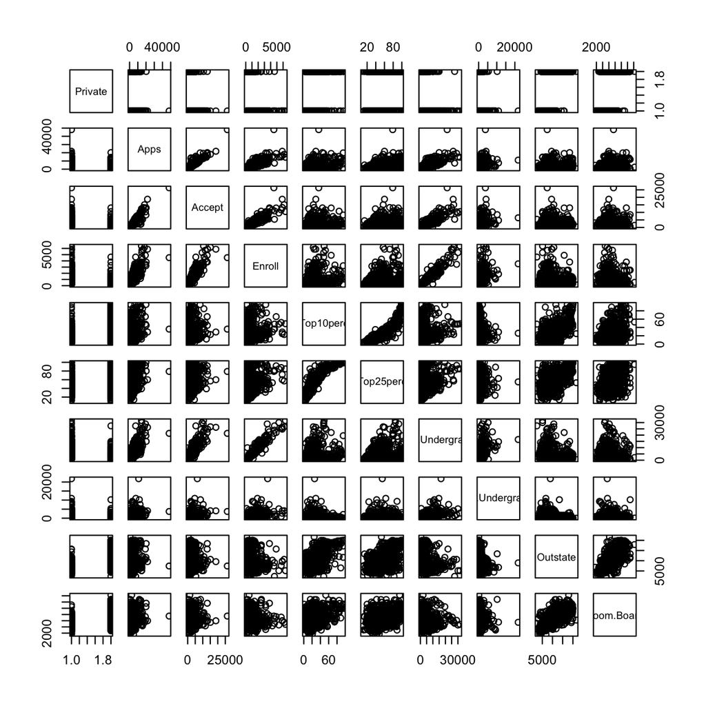

```r
pairs(college[1:10])
```

In the plots above there are many pairwise relationships. It appears that the there is a very strong relationship between `Enroll` and `F.Undergrad`. There also appears to be a strong relationship between `Outstate` and `Room.Board`.

### 1.c.iii

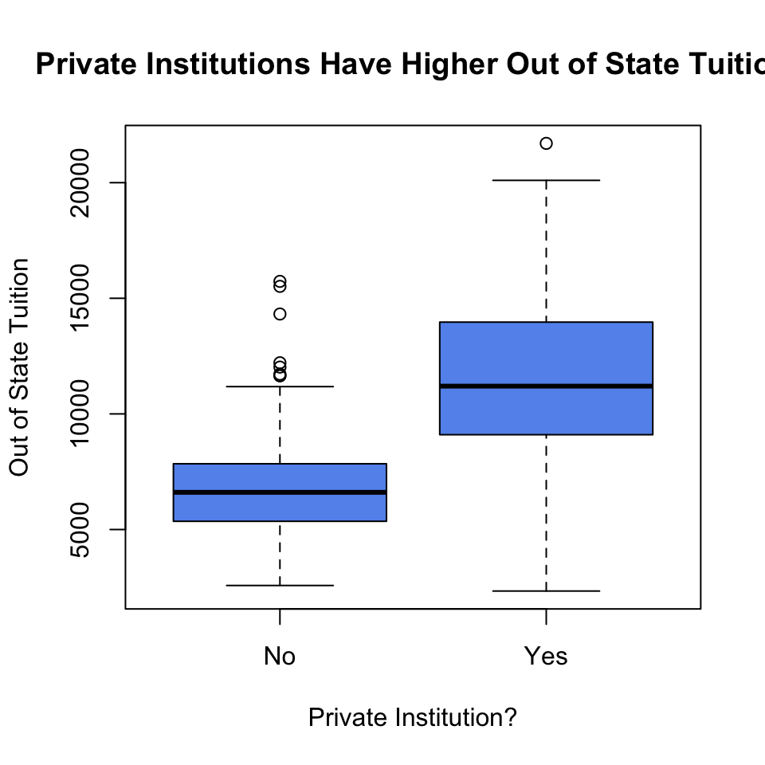

```r
# Create a boxplot where Private instituiton is the explantory varialbe and the response is Out of state Tuition.
par(mfrow = c(1,1))
plot(college$Private, college$Outstate, xlab = "Private Institution?",
     main = "Private Institutions Have Higher Out of State Tuition",
     ylab = "Out of State Tuition", col = "cornflowerblue")
```

In the figure above it is clear that private institutions have higher out of state tuition compared to public institutions. But by how much on average? Below in the table, we can see that the average out of state tuition in private institutions is $11802 while public instition out of state is $6813. Therefore, on average it costs $4989 more to go to a private instition.

```r
# Let's look at the summaries for Private
private_stats <- group_by(college, Private) %>%
  summarize(Avg.Outstate = mean(Outstate))

# Look at the average out of state for Private vs Public
panderOptions("digits", 2)
pander(private_stats)
```

| Private | Avg.Outstate |
| --- | --- |
| No | 6813 |
| Yes | 11802 |

### 1.c.iv

##### Create a New column called “Elite” by binning the `Top10perc` variable. An institution is `Elite` whenthe proportion of incoming students from the top 10% of their high school class exceeds 50%.

```r
Elite <- rep("No", nrow(college))
Elite[college$Top10perc >50] <- "Yes"
Elite <- as.factor(Elite)
college <- data.frame(college, Elite)

pander(summary(college$Elite))
```

| No | Yes |
| --- | --- |
| 699 | 78 |

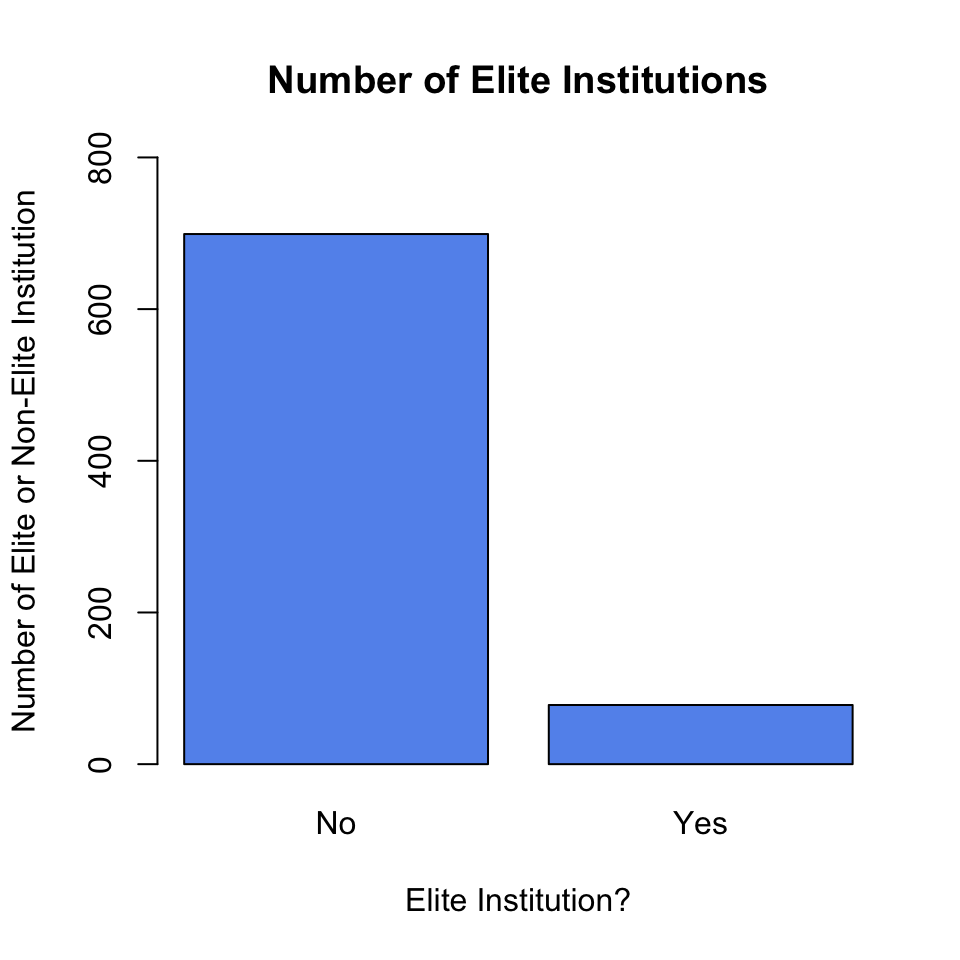

```r
plot(college$Elite, xlab = "Elite Institution?", ylim = c(0, 800),
     ylab = "Number of Elite or Non-Elite Institution", col = "cornflowerblue",
     main = "Number of Elite Institutions")
```

Out of the 777 institutions, 78 are elite. Therefore, 10.03861% are elite while 89.96139% are not elite.

### 1.c.v

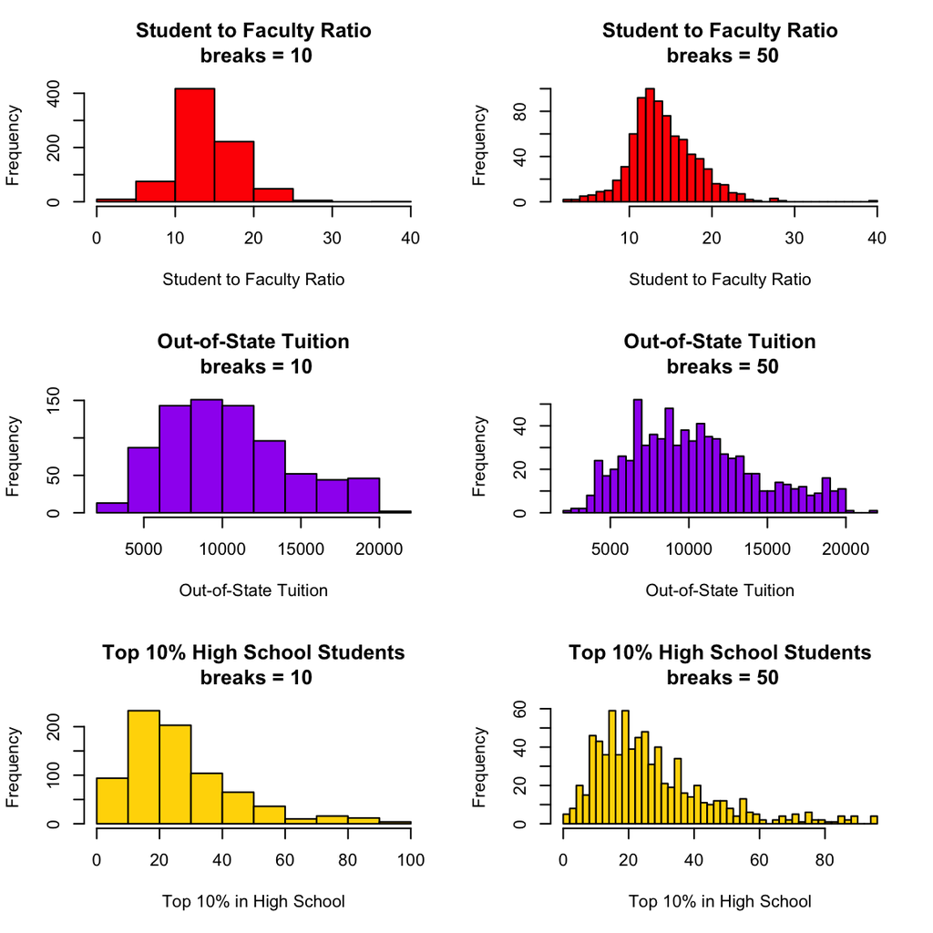

```r
par(mfrow = c(3,2))
hist(college$S.F.Ratio, main = "Student to Faculty Ratio\n breaks = 10",
     breaks = 10, col = "red", xlab = "Student to Faculty Ratio")
hist(college$S.F.Ratio, main = "Student to Faculty Ratio\n breaks = 50",
     breaks = 50, col = "red", xlab = "Student to Faculty Ratio")
hist(college$Outstate, main = "Out-of-State Tuition\n breaks = 10",
     breaks = 10, col = "purple", xlab = "Out-of-State Tuition")
hist(college$Outstate, main = "Out-of-State Tuition\n breaks = 50",
     breaks = 50, col = "purple", xlab = "Out-of-State Tuition")
hist(college$Top10perc, main = "Top 10% High School Students\n breaks = 10",
     breaks = 10, col = "gold", xlab = "Top 10% in High School")
hist(college$Top10perc, main = "Top 10% High School Students\n breaks = 50",
     breaks = 50, col = "gold", xlab = "Top 10% in High School")
```

Above are three different types of distributions. The **out of state tuition** is has the largest variance in the data while the **student to faculty ratio** has the highest frequency around 13 studnets per faculty and the **top 10% in high school** has the highest frequency around 15-20% of institions.

### 1.c.vi

```r
lm.10outstate <- lm(Top10perc ~ Outstate, data=college)
summary(lm.10outstate)
```

```
##
## Call:
## lm(formula = Top10perc ~ Outstate, data = college)
##
## Residuals:
##     Min      1Q  Median      3Q     Max
## -31.658 -10.110  -2.624   6.410  71.185
##
## Coefficients:
##              Estimate Std. Error t value Pr(>|t|)
## (Intercept) 1.8145749  1.4571929   1.245    0.213
## Outstate    0.0024657  0.0001302  18.931   <2e-16 ***
## ---
## Signif. codes:  0 '***' 0.001 '**' 0.01 '*' 0.05 '.' 0.1 ' ' 1
##
## Residual standard error: 14.6 on 775 degrees of freedom
## Multiple R-squared:  0.3162, Adjusted R-squared:  0.3153
## F-statistic: 358.4 on 1 and 775 DF,  p-value: < 2.2e-16
```

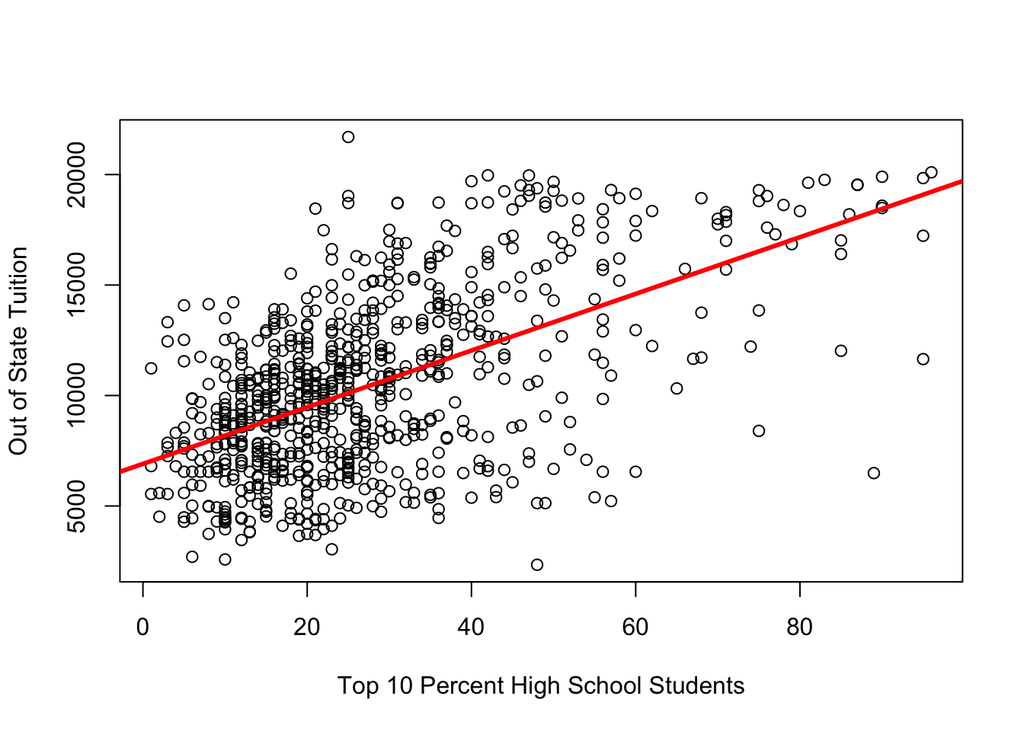

```r
par(mfrow = c(1,1))
plot(college$Top10perc, college$Outstate, xlab = "Top 10 Percent High School Students",
     ylab = "Out of State Tuition")
abline(lm(Outstate ~ Top10perc, data=college), lwd = 3, col = "red")
```

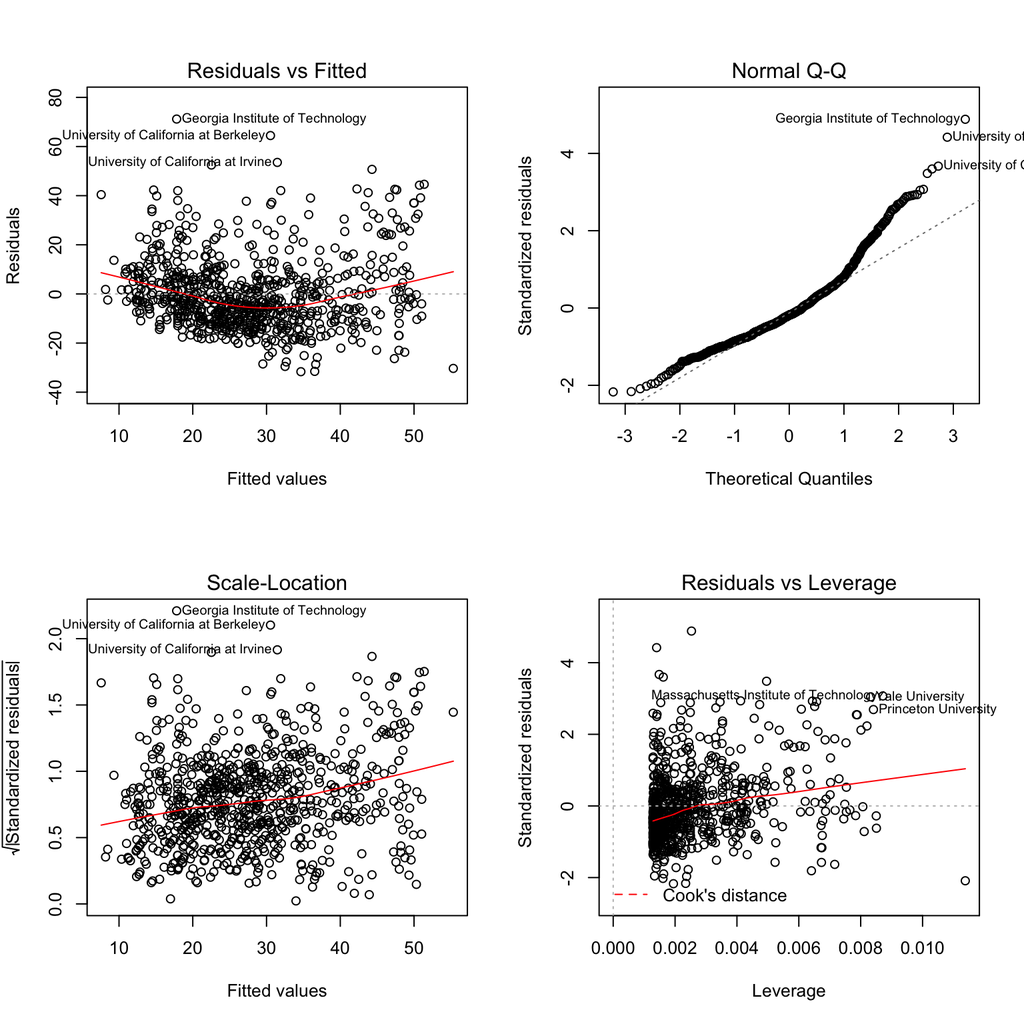

```r
par(mfrow = c(2,2))
plot(lm.10outstate)
```

### Question 2

#### Simple Linear Regression

```r
str(Carseats)
```

```
## 'data.frame':    400 obs. of  11 variables:
##  $ Sales      : num  9.5 11.22 10.06 7.4 4.15 ...
##  $ CompPrice  : num  138 111 113 117 141 124 115 136 132 132 ...
##  $ Income     : num  73 48 35 100 64 113 105 81 110 113 ...
##  $ Advertising: num  11 16 10 4 3 13 0 15 0 0 ...
##  $ Population : num  276 260 269 466 340 501 45 425 108 131 ...
##  $ Price      : num  120 83 80 97 128 72 108 120 124 124 ...
##  $ ShelveLoc  : Factor w/ 3 levels "Bad","Good","Medium": 1 2 3 3 1 1 3 2 3 3 ...
##  $ Age        : num  42 65 59 55 38 78 71 67 76 76 ...
##  $ Education  : num  17 10 12 14 13 16 15 10 10 17 ...
##  $ Urban      : Factor w/ 2 levels "No","Yes": 2 2 2 2 2 1 2 2 1 1 ...
##  $ US         : Factor w/ 2 levels "No","Yes": 2 2 2 2 1 2 1 2 1 2 ...
```

```r
help(Carseats)
colnames(Carseats)
```

```
##  [1] "Sales"       "CompPrice"   "Income"      "Advertising" "Population"
##  [6] "Price"       "ShelveLoc"   "Age"         "Education"   "Urban"
## [11] "US"
```

```r
# Simple linear regression
par(mfrow = c(1, 3))
plot(Carseats$Price, Carseats$Sales, xlab = "Price",
     ylab = "Sales", main = "Simple Regression")
lm.sales.price <- lm(Sales ~ Price, data = Carseats)
summary(lm.sales.price)
```

```
##
## Call:
## lm(formula = Sales ~ Price, data = Carseats)
##
## Residuals:
##     Min      1Q  Median      3Q     Max
## -6.5224 -1.8442 -0.1459  1.6503  7.5108
##
## Coefficients:
##              Estimate Std. Error t value Pr(>|t|)
## (Intercept) 13.641915   0.632812  21.558   <2e-16 ***
## Price       -0.053073   0.005354  -9.912   <2e-16 ***
## ---
## Signif. codes:  0 '***' 0.001 '**' 0.01 '*' 0.05 '.' 0.1 ' ' 1
##
## Residual standard error: 2.532 on 398 degrees of freedom
## Multiple R-squared:  0.198,  Adjusted R-squared:  0.196
## F-statistic: 98.25 on 1 and 398 DF,  p-value: < 2.2e-16
```

```r
abline(lm.sales.price)

plot(Carseats$Urban, Carseats$Sales, xlab = "Urban",
     ylab = "Sales", col = "red", main = "Urban?")
lm.sales.urban <- lm(Sales ~ Urban, data = Carseats)
summary(lm.sales.urban)
```

```
##
## Call:
## lm(formula = Sales ~ Urban, data = Carseats)
##
## Residuals:
##     Min      1Q  Median      3Q     Max
## -7.5636 -2.1107 -0.0109  1.7914  8.8018
##
## Coefficients:
##             Estimate Std. Error t value Pr(>|t|)
## (Intercept)  7.56356    0.26028  29.060   <2e-16 ***
## UrbanYes    -0.09537    0.30998  -0.308    0.759
## ---
## Signif. codes:  0 '***' 0.001 '**' 0.01 '*' 0.05 '.' 0.1 ' ' 1
##
## Residual standard error: 2.827 on 398 degrees of freedom
## Multiple R-squared:  0.0002378,  Adjusted R-squared:  -0.002274
## F-statistic: 0.09465 on 1 and 398 DF,  p-value: 0.7585
```

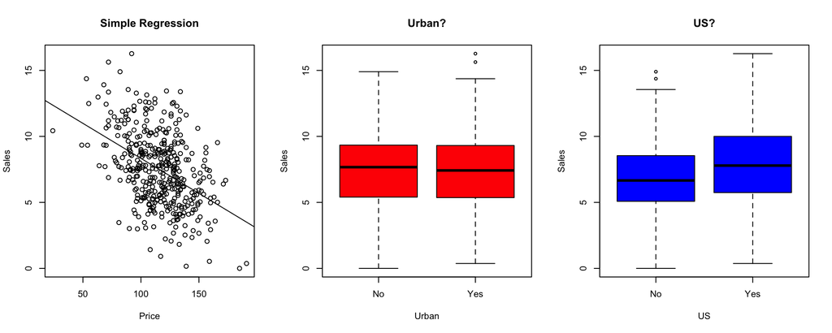

```r
plot(Carseats$US, Carseats$Sales, xlab = "US",
     ylab = "Sales", col = "blue", main = "US?")
```

```r
lm.sales.us <- lm(Sales ~ US, data = Carseats)
summary(lm.sales.us)
```

```
##
## Call:
## lm(formula = Sales ~ US, data = Carseats)
##
## Residuals:
##    Min     1Q Median     3Q    Max
## -7.497 -1.929 -0.105  1.836  8.403
##
## Coefficients:
##             Estimate Std. Error t value Pr(>|t|)
## (Intercept)   6.8230     0.2335   29.21  < 2e-16 ***
## USYes         1.0439     0.2908    3.59 0.000372 ***
## ---
## Signif. codes:  0 '***' 0.001 '**' 0.01 '*' 0.05 '.' 0.1 ' ' 1
##
## Residual standard error: 2.783 on 398 degrees of freedom
## Multiple R-squared:  0.03136,    Adjusted R-squared:  0.02893
## F-statistic: 12.89 on 1 and 398 DF,  p-value: 0.0003723
```

### 2a

#### Multiple Linear Regression

```r
# multiple linear regression
lm.sales <- lm(Sales ~ Price + Urban + US, data = Carseats)
summary(lm.sales)
```

```
##
## Call:
## lm(formula = Sales ~ Price + Urban + US, data = Carseats)
##
## Residuals:
##     Min      1Q  Median      3Q     Max
## -6.9206 -1.6220 -0.0564  1.5786  7.0581
##
## Coefficients:
##              Estimate Std. Error t value Pr(>|t|)
## (Intercept) 13.043469   0.651012  20.036  < 2e-16 ***
## Price       -0.054459   0.005242 -10.389  < 2e-16 ***
## UrbanYes    -0.021916   0.271650  -0.081    0.936
## USYes        1.200573   0.259042   4.635 4.86e-06 ***
## ---
## Signif. codes:  0 '***' 0.001 '**' 0.01 '*' 0.05 '.' 0.1 ' ' 1
##
## Residual standard error: 2.472 on 396 degrees of freedom
## Multiple R-squared:  0.2393, Adjusted R-squared:  0.2335
## F-statistic: 41.52 on 3 and 396 DF,  p-value: < 2.2e-16
```

### 2b

Above is a multiple linear regression of `Price`, `Urban`, and `US` trying to predict the `Sales` of carseats. The model explains 23.35% (adjusted R^2) of the variation in the data and is more likely to happen than by chance (p < 2.2e-16).

Based on the coefficients, we can see that `Price` is the best indicator of `Sales` and negatively influences the sales. In other words, as the price increases the sales decrease and this pattern is more likely to happen than by chance (p < 2.2e-16). Since the p-value is so low, **we can reject the null hypothesis.**

`Urban` on the other hand, is not significant as the p-value is 0.936 and **we CANNOT reject the null hypothesis**. We can see from the plots above that there’s very little difference between whether the carseats were bought in an urban environment or not. Therefore, `Urban` does not help us to predict `Sales`.

`US` is 2nd best indicator of `Sales` and positively impacts `Sales`. Therefore, if the carseats are sold in the United States, the sales increase by a coefficient of 1.2. Since the p-value is 4.86e-06, this pattern is more likely to happen than by chance and **we can reject the null hypothesis.**

### 2c

$Sales = B_1(Price) + B_2(Urban) + B_3(US) + B_0 + E$

Where:

- $B_1$ is the coefficient for Price
- $B_2$ is the coefficient for Urban
- $B_3$ is the coefficient for US
- $B_0$ is the y-intercept
- $E$ is the error

### 2e

```r
# Not including Urban
lm.noUrban <- lm(Sales ~ Price + US, data = Carseats)
summary(lm.noUrban)
```

```
##
## Call:
## lm(formula = Sales ~ Price + US, data = Carseats)
##
## Residuals:
##     Min      1Q  Median      3Q     Max
## -6.9269 -1.6286 -0.0574  1.5766  7.0515
##
## Coefficients:
##             Estimate Std. Error t value Pr(>|t|)
## (Intercept) 13.03079    0.63098  20.652  < 2e-16 ***
## Price       -0.05448    0.00523 -10.416  < 2e-16 ***
## USYes        1.19964    0.25846   4.641 4.71e-06 ***
## ---
## Signif. codes:  0 '***' 0.001 '**' 0.01 '*' 0.05 '.' 0.1 ' ' 1
##
## Residual standard error: 2.469 on 397 degrees of freedom
## Multiple R-squared:  0.2393, Adjusted R-squared:  0.2354
## F-statistic: 62.43 on 2 and 397 DF,  p-value: < 2.2e-16
```

$Sales = B_1(Price) + B_2(US) + B_0 + E$

Where:

- $B_1$ is the coefficient for Price
- $B_2$ is the coefficient for US
- $B_0$ is the y-intercept
- $E$ is the error

The model above that does not include `Urban` and still explains 23.54% (adjusted R^2) of the variation in the data and is more likely to happen than by chance (p < 2.2e-16). Compared with the previous model that does inclue `Urban`, here we gain explanatory power over 0.19% of the variation in the data (change in R2).